# Hello there ....

[figure not shown]

This is a demonstration tutorial for the Citizen-Q project, http://www.citizen-q.org.

To navigate to the tutorial, press space, to enhance the viewing experience, put your browser in fullscreen mode (press F11)

# How this works....

This is a fully interactive tutorial, where the participants can interact with the simulator using the python programming language. You should be able to edit the code in the cell below. Press shift-enter to execute the code in the cell.

```python
#This is python code
1+3
```

```
4
```

## Classical information

In existing computers, the smallest unit of information is the *bit*, that can be in one of two states, here denoted as $|0\rangle$ and $|1\rangle$. In this tutorial we will represent information as a point on a sphere. Classical information can only be points on the northpole and southpole.

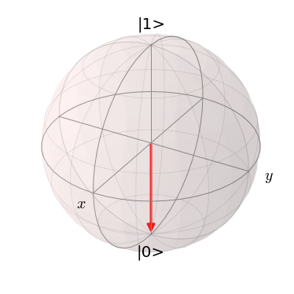

```python
%matplotlib inline
from citizen_q import *
draw_ground()
```

## From bits to qubits

In quantum information processing, the smallest unit of information is the *qubit* that is, similarly to the classical case, embedded in a two-level system. Since the qubit is a quantum object it can also be in a *quantum superposition* of the two states. The most general state $|\Psi \rangle$ of the qubit can be written as:

$\Psi = \alpha |0\rangle + \beta |1\rangle$

Due to the interpretation of the quantum state as a probability amplitude, the complex coefficients $\alpha$ and $\beta$ need to be normalized: $\alpha^2 + \beta^2 = 1$.

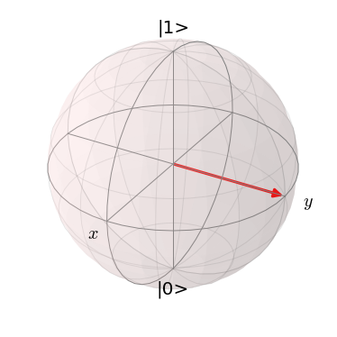

```python
draw_superposition()
```

The sphere above corresponds to the state $|\Psi_1\rangle = 1/ \sqrt{2} \, (|0 \rangle + |1\rangle$ which is known as a superposition state that has no classical analogon.

## Creating a superposition

Let's create a superposition from a classical state. First, we will need a qubit in the ground state which is already defined in our helper library.

```python
psi = ground_state()
```

The state of a qubit can then be manipulated by performing *rotations* around axes on the Bloch sphere. For example, we will rotate the ground state by 45° around the x-axis, which we can so by multiplying the state with the python command *rx(angle)*

```python
psi45 = rx(pi/4)*psi
```

The resulting state can then be displayed using the command show_sphere()

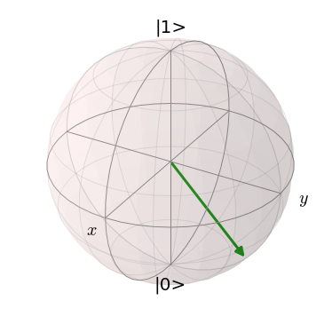

```python
show_sphere(psi45)
```

It's time for your first task. Using the formalism introduced above, generate an equal superposition between the two states $|0\rangle$ and $|1\rangle$. Type your code in the line below. Press shift-enter after editing to show your results.

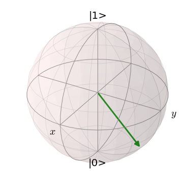

```python
%matplotlib inline
from citizen_q import *
psi = ground_state()
# Edit the next line to generate an equal superposition (hint: use rx() * psi)
psi90 = rx(pi/4) * psi
show_sphere(psi90)
```

We will now compare the generated state with the target state. Analogous to vector algebra, we will use the inner product between two state vectors as a measure. In quantum information theory, this measure is called the *fidelity*

```python
check_fidelity(psi90)
```

```
Your fidelity is 0.8535533905932737
Your fidelity did not reach the threshold
```